# Vignette for reading and summarizing data from API’s

Demetrios Samaras

2023-06-16

# Purpose

##### The purpose of this Vignette is to summarize how to interact with, pull data and then analyze the data from the pokemon data API https://pokeapi.co/.

# Required packages

##### The following packages will be required

- **tidyverse**
  - We will use a number of the functions from the tidyverse
- **jsonlite**
  - This will help up interact with the API
- **httr**
  - for the `GET` function
- **ggplot2**
  - This will be required to create the data visualizations (comes in tidyverse)

# Functions for querying endpoints

### Step 0

Make sure all of the required packages are installed using the `install.packages()` function and library them using `library()`

```r
library(tidyverse)
library(jsonlite)
library(httr)
library(ggplot2)
```

## Contact the API

This is the general format that we will use to contact the api and retrieve data (One thing to note is that the Pokemon API does not require a key, many other API’s will require you to use your specific key included at the end of the URL)

```r
## this is a functin to contact the API from a url
query <- function(x){
  ## will generate a url with the desired endpoint and inputed data
  url<- x

 ## contact the api  and store the response
 response <-GET(x)
 ## converts raw to charecter
 data <- rawToChar(response$content)
 ## converts from json data
 jsondata <- fromJSON(data)
 ## organizes results of interest in a tibble and prints
 tibbleresults <- as_tibble(jsondata$ResultOfInterest)

 tibbleresults

}
```

## Interacting with the Pokemon API endpoints.

### Pokemon `WhosThatPokemon` endpoint 1

This function will return a list of Pokemon and their ID number. As of writing there are 1281 Pokemon so by default it will return a tibble containing the names of all Pokemon in order. If you only wanted to see the first n number of Pokemon you would set n equal to that number. For example n=151 will return only the first 151 Pokemon. If you have a specific Pokemon in mind you can give the name or ID as pokemon=“name” or pokemon=ID which will return a the information available about that specific pokemon. If you know the information that you want on that pokemon you can set info equal to the info of interest. For example if want the weight set info=“weight”.

```r
## https://pokeapi.co/api/v2/pokemon/

WhosThatPokemon <- function(pokemon="all", n=1281, info=NULL){
  ## if you want all Pokemon between 1 and your number of interest n
  if(n>1281){
    ## kicks out the user if n is larger than what is available from the api
    stop("There are only 1281 pokemon")
  }
  if(pokemon=="all"){

 n == n
 ## creates the url to contact
 url <- paste0("https://pokeapi.co/api/v2/pokemon/", "?limit=", n )

 response <-GET(url)

 data <- rawToChar(response$content)

 jsondata <- fromJSON(data)

 data<- as_tibble(jsondata$results)
 ## gets rid of the url column and adds a new column containing id numbers
 data1<- data %>% select(name) %>% mutate(ID=1:n)

  }
 ## this returns info available on the specific Pokemon or ID number
  if(pokemon!= "all"&is.null(info)){
 ## generates url containing Pokemon name or ID of interest
 url <- paste0("https://pokeapi.co/api/v2/pokemon/", pokemon, "/" )

 response <-GET(url)

 data <- rawToChar(response$content)

 jsondata <- fromJSON(data)
 ## gives the available info on this Pokemon
 data1<- as_tibble(names(jsondata))

  }
  if(pokemon!="all"& !is.null(info)){
  url <- paste0("https://pokeapi.co/api/v2/pokemon/", pokemon, "/" )

  #"https://pokeapi.co/api/v2/pokemon/bulbasaur/

 response <-GET(url)

 data <- rawToChar(response$content)

 jsondata <- fromJSON(data)
 ## gives the desired info on this Pokemon
 data1 <- as_tibble(jsondata[info])


  }
  data1
}
```

### Berry `WhichBerry` endpoint 2

This function will return a list of berries and their ID number. If you only wanted to see the first n number of berries you would set n equal to that number. For example n=10 will return only the first 10 berries. If you have a specific berry in mind you can give the name or ID as berry=“name” or berry=ID which will return a the information available about that specific berry. If you know the information that you want on that berry you can set info equal to the info of interest. For example if want the smoothness set info=“smoothness”.

```r
WhichBerry <- function(berry="all", n=64, info=NULL){
  ## if you want all berries between 1 and your number of interest n
  if(n>64){
    ## kicks out the user if n is larger than what is available from the api
    stop("There are only 64 berries")
  }

  if(berry=="all"){

 n == n
 ## creates the url to contact
 url <- paste0("https://pokeapi.co/api/v2/berry/", "?limit=", n )

 response <-GET(url)

 data <- rawToChar(response$content)

 jsondata <- fromJSON(data)

 data<- as_tibble(jsondata$results)
 ## gets rid of the url column and adds a new column containing id numbers
 data1<- data %>% select(name) %>% mutate(ID=1:n)

  }
 ## this returns info available on the specific berry or ID number
  if(berry!= "all"&is.null(info)){
 ## generates url containing berry name or ID of interest
 url <- paste0("https://pokeapi.co/api/v2/berry/", berry, "/" )

 response <-GET(url)

 data <- rawToChar(response$content)

 jsondata <- fromJSON(data)
 ## gives the available info on this berry
 data1<- as_tibble(names(jsondata))

  }
  if(berry!="all"& !is.null(info)){
  url <- paste0("https://pokeapi.co/api/v2/berry/", berry, "/" )



 response <-GET(url)

 data <- rawToChar(response$content)

 jsondata <- fromJSON(data)
 ## gives the desired info on this berry
 data1 <- as_tibble(jsondata[[info]])


  }
  data1
}
```

### Generation `WhatGeneration` endpoint 3

This function will return a list of generations and their ID number. If you only wanted to see the first n number of generations you would set n equal to that number. For example n=9 will return all 9 generations. If you have a specific generation in mind you can give the name or ID as gen=“name” or gen=ID which will return the information available about that specific generation. If you know the information that you want on that generation you can set info equal to the info of interest. For example if want the types of pokemon in that generations set info=“types”.

```r
WhatGeneration <- function(gen="all", n=9, info=NULL){
  ## if you want all between 1 and your number of interest n
  if(n>9){
    ## kicks out the user if n is larger than what is available from the api
    stop("There are only 9 generations")
  }
  if(gen=="all"){

 n == n
 ## creates the url to contact
 url <- paste0("https://pokeapi.co/api/v2/generation/", "?limit=", n )

 response <-GET(url)

 data <- rawToChar(response$content)

 jsondata <- fromJSON(data)

 data<- as_tibble(jsondata$results)
 ## gets rid of the url column and adds a new column containing id numbers
 data1<- data %>% select(name) %>% mutate(ID=1:n)

  }
 ## this returns info available on the specific generation or ID number
  if(gen!= "all"&is.null(info)){
 ## generates url containing generation name or ID of interest
 url <- paste0("https://pokeapi.co/api/v2/generation/", gen, "/" )

 response <-GET(url)

 data <- rawToChar(response$content)

 jsondata <- fromJSON(data)
 ## gives the available info on this generation
 data1<- as_tibble(names(jsondata))

  }
  if(gen!="all"& !is.null(info)){
  url <- paste0("https://pokeapi.co/api/v2/generation/", gen, "/" )


 response <-GET(url)

 data <- rawToChar(response$content)

 jsondata <- fromJSON(data)
 ## gives the desired info on this generation
 data1 <- as_tibble(jsondata[[info]])


  }
  data1
}
```

### Contest-type`ContestTypes` endpoint 4

This function will return a list of contest types and their ID number. If you only wanted to see the first n number of contest types you would set n equal to that number. For example n=5 will return all contest types. If you have a specific contest in mind you can give the name or ID as con=“name” or con=ID which will return the information available about that specific contest type. If you know the information that you want on that contest type you can set info equal to the info of interest. For example if want the berry flavor that correlates with this contest type set info=“berry_flavor”.

```r
ContestTypes <- function(con="all", n=5, info=NULL){
  ## if you want all  between 1 and your number of interest n
  if(n>5){
    ## kicks out the user if n is larger than what is available from the api
    stop("There are only 5 contest types")
  }
  if(con=="all"){

 n == n
 ## creates the url to contact
 url <- paste0("https://pokeapi.co/api/v2/contest-type/", "?limit=", n )

 response <-GET(url)

 data <- rawToChar(response$content)

 jsondata <- fromJSON(data)

 data<- as_tibble(jsondata$results)
 ## gets rid of the url column and adds a new column containing id numbers
 data1<- data %>% select(name) %>% mutate(ID=1:n)

  }
 ## this returns info available on the specific contest type or ID number
  if(con!= "all"&is.null(info)){
 ## generates url containing contest type or ID of interest
 url <- paste0("https://pokeapi.co/api/v2/contest-type/", con, "/" )

 response <-GET(url)

 data <- rawToChar(response$content)

 jsondata <- fromJSON(data)
 ## gives the available info on this contest type
 data1<- as_tibble(names(jsondata))

  }
  if(con!="all"& !is.null(info)){
  url <- paste0("https://pokeapi.co/api/v2/contest-type/", con, "/" )



 response <-GET(url)

 data <- rawToChar(response$content)

 jsondata <- fromJSON(data)
 ## gives the desired info on this contest type
 data1 <- as_tibble(jsondata[[info]])


  }
  data1
}
```

### Item `GotItem` endpoint 5

This function will return a list of items and their ID number. If you only wanted to see the first n number of items you would set n equal to that number. For example n=10 will return only the first 10 items. If you have a specific item in mind you can give the name or ID as item=“name” or item=ID which will return the information available about that specific item. If you know the information that you want on that item you can set info equal to the info of interest. For example if want the cost set info=“cost”.

```r
GotItem <- function(item="all", n=2050, info=NULL){
  ## if you want all between 1 and your number of interest n
  if(n>2050){
    ## kicks out the user if n is larger than what is available from the api
   stop("There are only 2050 items")
  }
  if(item=="all"){

 n == n
 ## creates the url to contact
 url <- paste0("https://pokeapi.co/api/v2/item/", "?limit=", n )

 response <-GET(url)

 data <- rawToChar(response$content)

 jsondata <- fromJSON(data)

 data<- as_tibble(jsondata$results)
 ## gets rid of the url column and adds a new column containing id numbers
 data1<- data %>% select(name) %>% mutate(ID=1:n)

  }
 ## this returns info available on the specific item or ID number
  if(item!= "all"&is.null(info)){
 ## generates url containing item name or ID of interest
 url <- paste0("https://pokeapi.co/api/v2/item/", item, "/" )

 response <-GET(url)

 data <- rawToChar(response$content)

 jsondata <- fromJSON(data)
 ## gives the available info on this item
 data1<- as_tibble(names(jsondata))

  }
  if(item!="all"& !is.null(info)){
  url <- paste0("https://pokeapi.co/api/v2/item/", item, "/" )



 response <-GET(url)

 data <- rawToChar(response$content)

 jsondata <- fromJSON(data)
 ## gives the desired info on this item
 data1 <- as_tibble(jsondata[[info]])


  }
  data1
}
```

### Location `WhereAmI` endpoint 6

This function will return a list of locations and their ID number. If you only wanted to see the first n number of locations you would set n equal to that number. For example n=10 will return only the first 10 locations. If you have a specific location in mind you can give the name or ID as loc=“name” or loc=ID which will return a the information available about that specific location. If you know the information that you want on that location you can set info equal to the info of interest. For example if want the region set info=“region”.

```r
WhereAmI <- function(loc="all", n=850, info=NULL){
  ## if you want all between 1 and your number of interest n
  if(n>850){
    ## kicks out the user if n is larger than what is available from the api
    stop("There are only 850 locations")
  }

  if(loc=="all"){

 n == n
 ## creates the url to contact
 url <- paste0("https://pokeapi.co/api/v2/location/", "?limit=", n )

 response <-GET(url)

 data <- rawToChar(response$content)

 jsondata <- fromJSON(data)

 data<- as_tibble(jsondata$results)
 ## gets rid of the url column and adds a new column containing id numbers
 data1<- data %>% select(name) %>% mutate(ID=1:n)

  }
 ## this returns info available on the specific location or ID number
  if(loc!= "all"&is.null(info)){
 ## generates url containing location name or ID of interest
 url <- paste0("https://pokeapi.co/api/v2/location/", loc, "/" )

 response <-GET(url)

 data <- rawToChar(response$content)

 jsondata <- fromJSON(data)
 ## gives the available info on this location
 data1<- as_tibble(names(jsondata))

  }
  if(loc!="all"& !is.null(info)){
  url <- paste0("https://pokeapi.co/api/v2/location/", loc, "/" )


 response <-GET(url)

 data <- rawToChar(response$content)

 jsondata <- fromJSON(data)
 ## gives the desired info on this location
 data1 <- as_tibble(jsondata[[info]])


  }
  data1
}
```

### `GiveMeThisInfo`

This function will use our 6 endpoint functions to pull info from whichever endpoint is desired by setting fun=desired function to help with our EDA. For example say you want costs for items ID 25 - 42 or a random sample of pokemon and their heights. This function takes a vector of names **or** a vector of ID’s that are supplied by the user and info = “desired info”. The desired info must return a single integer, for example height, weight, size, cost, etc.

```r
GiveMeThisInfo <- function(fun = WhosThatPokemon, vec, info=NULL){

  ## checks if the vector input is numeric
  if(is.numeric(vec)){

  ##creates index of all from the desired function
  index <- fun()

  ## adjusts the index to be the ID of interest
  index <- subset(index, ID %in% vec)

  ## applies the function to ID's of interest
  ThesePokemon <-sapply(X=vec, FUN = fun, info = info)
  ThesePokemon <- unlist(ThesePokemon)

  ## creates a data frame with names
  p<- data.frame(name=index$name, ID=index$ID , info=ThesePokemon)
  ## sets the name of the column with desired info to the info requested
  names(p)[3] <- info

  return(as_tibble(p))
  }
else{
  index <- fun()
  ## adjusts the index to be name of interest
  index <- subset(index, name %in% vec)

  ## applies the  function to names of interest
  ThesePokemon <-sapply(X=vec, FUN = fun, info = info)
  ThesePokemon <- unlist(ThesePokemon)

  ## creates a data frame with names
  p<- data.frame(name=index$name, ID=index$ID , info=ThesePokemon, row.names = NULL)
  ## sets the name of the column with desired info to the info requested
  names(p)[3] <- info

  return(as_tibble(p))

 }
}
```

# EDA

### Berry sizes

Here we will look at the size distribution of all berries using the functions we created. This will return a tibble that has all 64 berries and their sizes.

```r
## grabs all the berries
Berries <- GiveMeThisInfo(fun = WhichBerry, vec = 1:64, info = "size")

Berries
```

| name | ID | size |
| --- | --- | --- |
| cheri | 1 | 20 |
| chesto | 2 | 80 |
| pecha | 3 | 40 |
| rawst | 4 | 32 |
| aspear | 5 | 50 |
| leppa | 6 | 28 |
| oran | 7 | 35 |
| persim | 8 | 47 |
| lum | 9 | 34 |
| sitrus | 10 | 95 |

[output cut: 54 more lines]

Here we will categorize the berries into size and look at how many fall into each group. We can see that the largest number of berries fall into the small size category, none are tiny and a similar amount fall into medium and large.

```r
## categorizes the berries based on size
 BerrySize<- ifelse(Berries$size >= 200, "large",
      ifelse(Berries$size >= 100, "medium",
        ifelse(Berries$size >= 10, "small", "tiny")))
## makes a contigency table of the size categories
table(BerrySize)
```

```
## BerrySize
##  large medium  small
##     14     18     32
```

Looking at the frequency histogram We can see that berry size does not seem to be symmetrically distributed and has a long right tail.

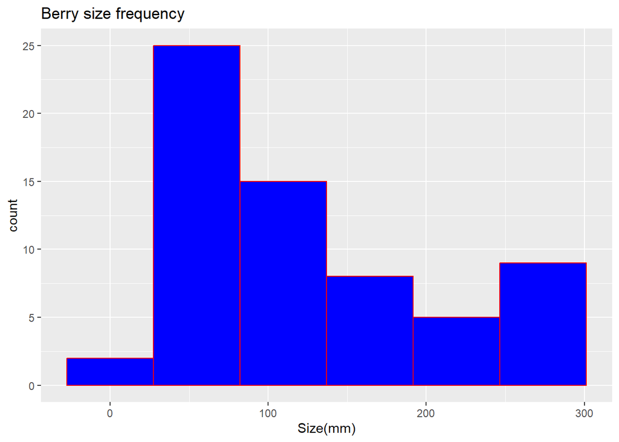

```r
## estimates a decent binwidth
bw <- 2 * IQR(Berries$size) / length(Berries$size)^(1/3)
##sets plotting object
h <- ggplot(Berries, aes(x=size))
## makes histogram
h+geom_histogram(binwidth = bw, color="red", fill="blue") + labs(x="Size(mm)") + ggtitle("Berry size frequency")
```

### Pokemon heights, weights and types

We are going to use the functions that we created to figure out how many pokemon are in generation 1 and get the heights and weights and types of all of the pokemon in generation 1 to look at the relationship.

```r
## gives us a count of all the pokemon in the first generation
gen1<- WhatGeneration(gen=1, info="pokemon_species") %>% nrow()

## contacts the api to get the heights for the first generation of pokemon
Gen1PokeHeights <- GiveMeThisInfo(fun = WhosThatPokemon, vec=1:gen1, info = "height")

## contacts the api to get the weights for the first generation of pokemon
Gen1PokeWeights <- GiveMeThisInfo(fun = WhosThatPokemon, vec =1:gen1, info = "weight")

## types does not return a single integer so we will use sapply to get types
Gen1PokeTypes <- sapply(X=c(1:gen1), FUN = WhosThatPokemon, info = "types")

## pulls the primary type out for each pokemon
Gen1PokeTypes <- sapply(1:gen1, FUN = function(i){ Gen1PokeTypes[[i]][[2]][1,1]})

## takes primary type as a tiblle
Gen1PokeTypes<- Gen1PokeTypes%>% as_tibble()

## renames column
names(Gen1PokeTypes) <- "type"

## binds the column of heights, weights, and types together

Gen1PokeHWT <- cbind(Gen1PokeHeights, select(Gen1PokeWeights, "weight"), select(Gen1PokeTypes, "type"))

Gen1PokeHWT
```

| name | ID | height | weight | type |
| --- | --- | --- | --- | --- |
| bulbasaur | 1 | 7 | 69 | grass |
| ivysaur | 2 | 10 | 130 | grass |
| venusaur | 3 | 20 | 1000 | grass |
| charmander | 4 | 6 | 85 | fire |
| charmeleon | 5 | 11 | 190 | fire |
| charizard | 6 | 17 | 905 | fire |
| squirtle | 7 | 5 | 90 | water |
| wartortle | 8 | 10 | 225 | water |
| blastoise | 9 | 16 | 855 | water |
| caterpie | 10 | 3 | 29 | bug |

[output cut: 141 more lines]

In the following histograms we can see that the distribution of the heights and weights are both centered at the lower end with long right tails. This suggests that while most pokemon are similar sizes there are some that are incredibly tall and heavy.

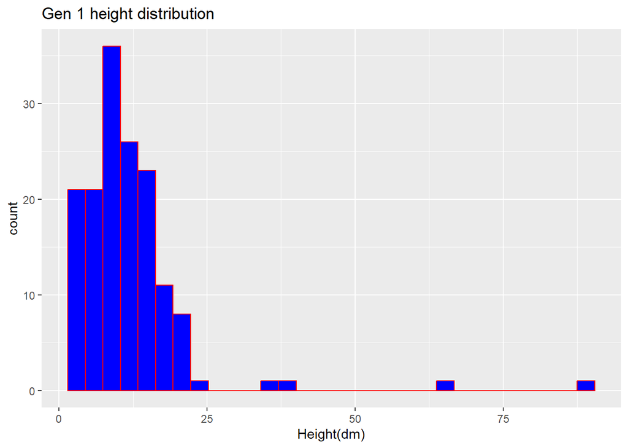

```r
n <- ggplot(Gen1PokeHWT, aes(x=height))

n+ geom_histogram(color="red", fill="blue")+labs(x="Height(dm)")+ggtitle("Gen 1 height distribution")
```

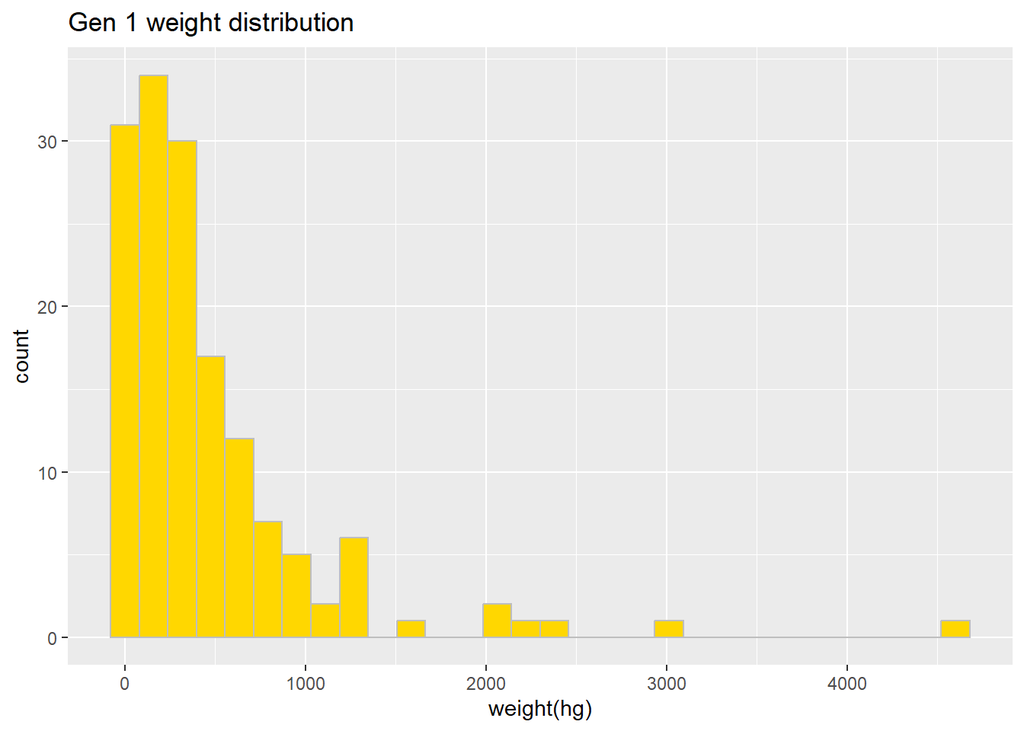

```r
n <- ggplot(Gen1PokeHWT, aes(x=weight))

n+ geom_histogram(color="grey", fill="gold")+labs(x="weight(hg)")+ggtitle("Gen 1 weight distribution")
```

Here we can look at the relationship between the heights and the weights of Pokemon based on there types. There is some correlation between heights and weights, we can see that in general as weights increase so do heights but there are some extreme examples of both that don’t follow the trend line. There doesn’t seem to be an obvious relationship between type and either size or weight based on this plot.

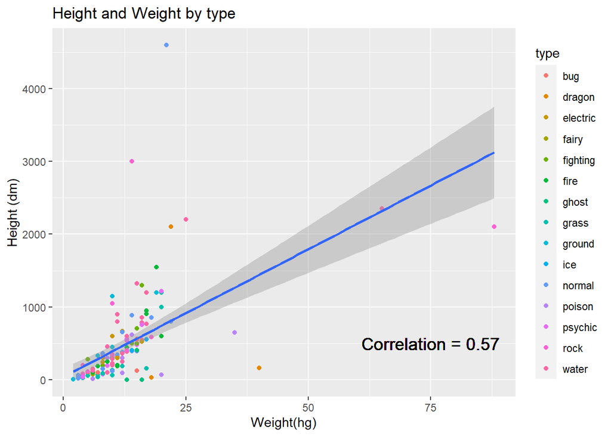

```r
## correlation between height and weight
correlation <- cor(Gen1PokeHWT$height, Gen1PokeHWT$weight)
## sets the plotting object as Gen1PokeHWT
s <- ggplot(Gen1PokeHWT, aes(x=height, y=weight))
## adds scatter and line
s+geom_point(aes(color=type)) + geom_smooth(method = lm) +labs(y= "Height (dm)", x="Weight(hg)")+ggtitle("Height and Weight by type") + geom_text( x=75, y=500, size = 5, label = paste0("Correlation = ",
round(correlation, 2)))
```

This is a contingency table of the number of each type of Pokemon followed by a bar plot of that count, we can see that water is the most common type followed by normal. Ice and fairy are the least common types

```r
## generates contingency table of type count
TypeFeq <- table(Gen1PokeHWT$type)

TypeFeq
```

```
##
##      bug   dragon electric    fairy fighting     fire    ghost    grass
##       12        3        9        2        7       12        3       12
##   ground      ice   normal   poison  psychic     rock    water
##        8        2       22       14        8        9       28
```

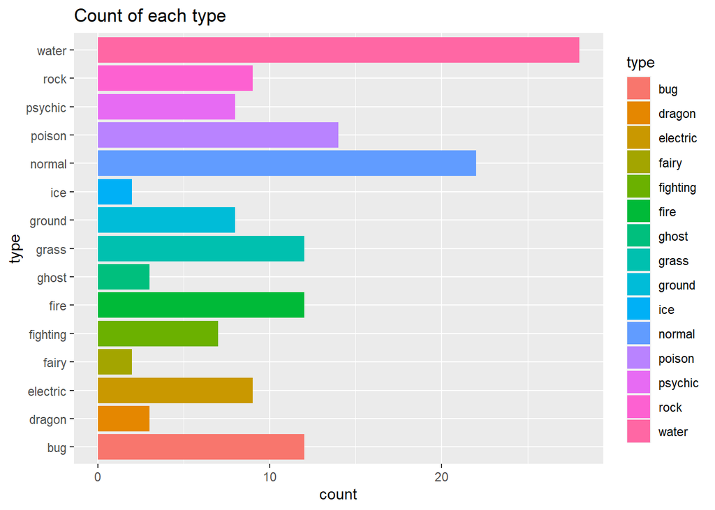

```r
f <- ggplot(data = Gen1PokeHWT, aes(y=type, fill=type))

f + geom_bar(stat = "count", ) + ggtitle("Count of each type")
```

### Pokemon Linear density

Here we will create a new variable from two of our variables height and weight. We will take weight/height and treat it as linear density and look at the average density for each setting of our categorical variable type.

```r
## creates new column density that is weight/height
Gen1PokeHWT$density<- (Gen1PokeHWT$weight/Gen1PokeHWT$height)

Gen1PokeHWT
```

| name | ID | height | weight | type | density |
| --- | --- | --- | --- | --- | --- |
| bulbasaur | 1 | 7 | 69 | grass | 9.85714286 |
| ivysaur | 2 | 10 | 130 | grass | 13.00000000 |
| venusaur | 3 | 20 | 1000 | grass | 50.00000000 |
| charmander | 4 | 6 | 85 | fire | 14.16666667 |
| charmeleon | 5 | 11 | 190 | fire | 17.27272727 |
| charizard | 6 | 17 | 905 | fire | 53.23529412 |
| squirtle | 7 | 5 | 90 | water | 18.00000000 |
| wartortle | 8 | 10 | 225 | water | 22.50000000 |
| blastoise | 9 | 16 | 855 | water | 53.43750000 |
| caterpie | 10 | 3 | 29 | bug | 9.66666667 |

[output cut: 141 more lines]

by creating a box plot of densities for each type we can see that for some types the density is fairly symmetrical, whereas for others it is highly skewed, like for type=dragon.

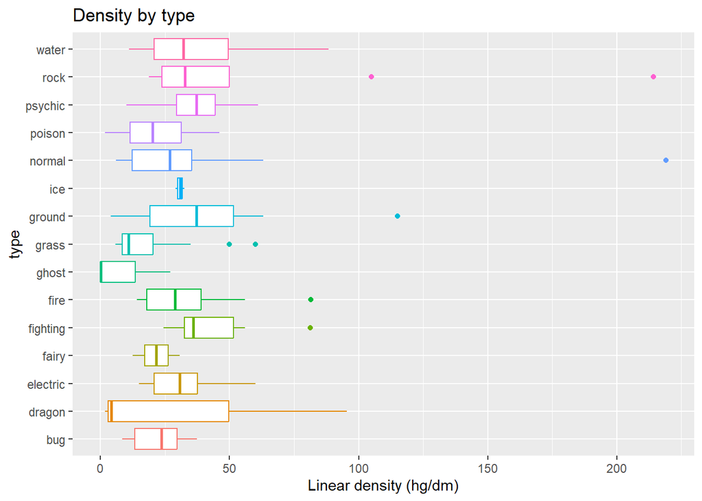

```r
## creates a plotting object with density vs type
b <- ggplot(Gen1PokeHWT, aes(y=type, x=density, color=type))
## creats a set of boxplots of density vs type
b + geom_boxplot(show.legend = FALSE) + labs(x="Linear density (hg/dm)")+ggtitle("Density by type")
```

# Conclusion

To summarize this vignette, we were able to create a number of functions that allow the user to query a number of endpoints and extract desired information into a form that allows for easy understanding and analysis. We also used these functions to do a basic data analysis to check the functionality and to look at some interesting data.